# Evolución casos COVID19 en España: datos básicos

J. J. Merelo

8 de octubre de 2020

Este artículo muestra la evolución de los casos de COVID-19 en España, con datos oficiales del Ministerio de Sanidad recogidos por [el Datadista](https://github.com/datadista/datasets). Incluye gráficas básicas de evolución del *case fatality rate*, es decir, la relación entre el número de casos totales acumulado y el número de decesos acumulado.

**Nota**: estos son datos proporcionados por el ministerio y de fiabilidad dudosa. Se han eliminado todos los cálculos que usan como base el número de hospitalizados y de ingresos en la UCI, puesto que el Ministerio de Sanidad ha cometido un error sumando los datos de comunidades que comunican los que permanecen ingresados, con los datos de otras que comunican los ingresos totales desde el principio.

Este es el porcentaje de fallecimientos con respecto al número de casos reformados:

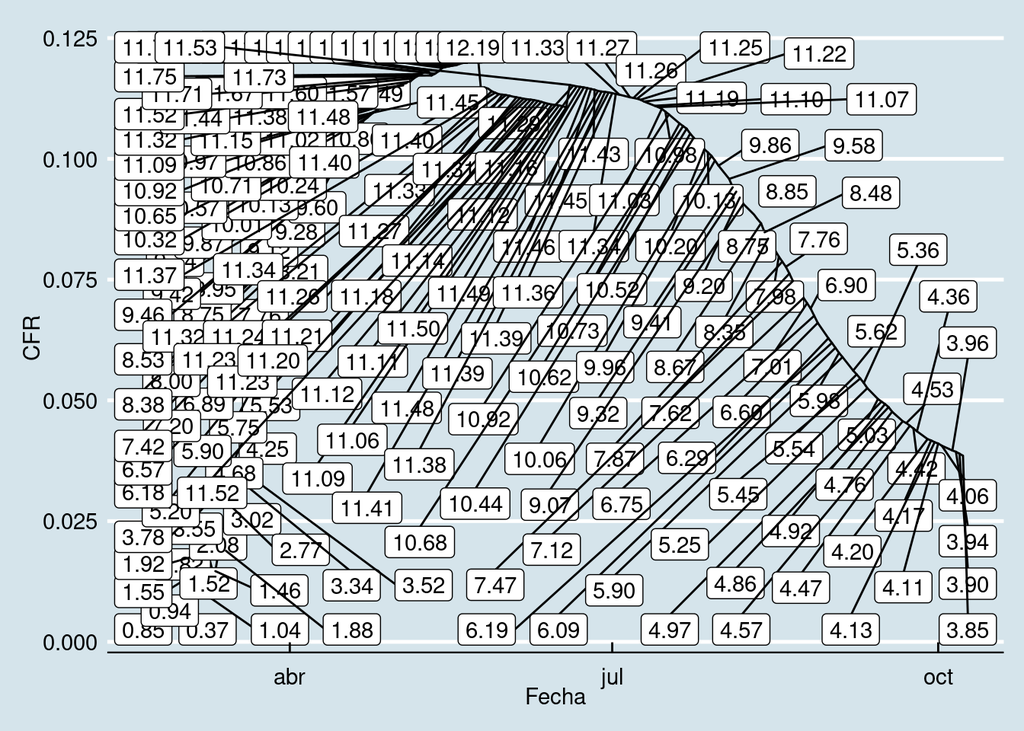

```r
library(ggrepel)
ggplot(data,aes(x=Fecha,y=CFR))+geom_line()+theme_economist()+
  geom_label_repel(aes(label = sprintf("%.2f", CFR*100), hjust=0))
```

Se habla de `R0` como la relación de personas infectadas por cada una que tenga COVID-19. La estimación directa es imposible, pero de forma indirecta se puede estimar a partir del número nuevo de casos, comparando con el número total de casos del día anterior.

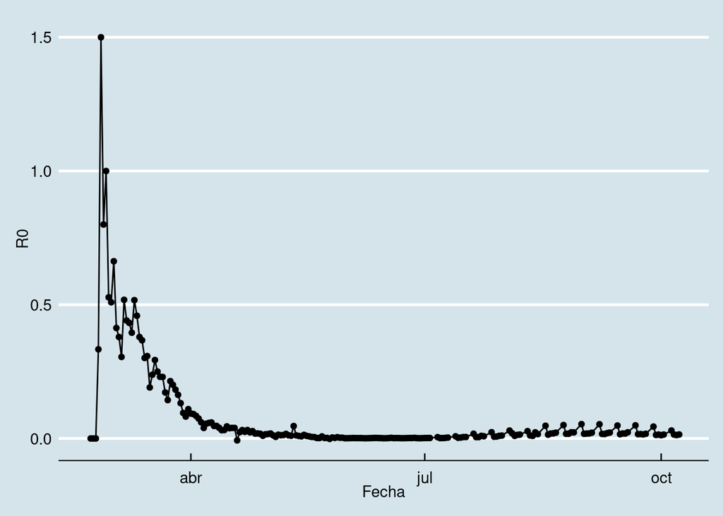

```r
ggplot(data,aes(x=Fecha,y=R0))+geom_point()+geom_line()+theme_economist()
```

La tasa de resolución absoluta es la relación entre casos resueltos (positiva y negativamente) y casos totales. Dado que todos los datos en el mismo son inciertos, interesa más la dinámica que los valores absolutos:

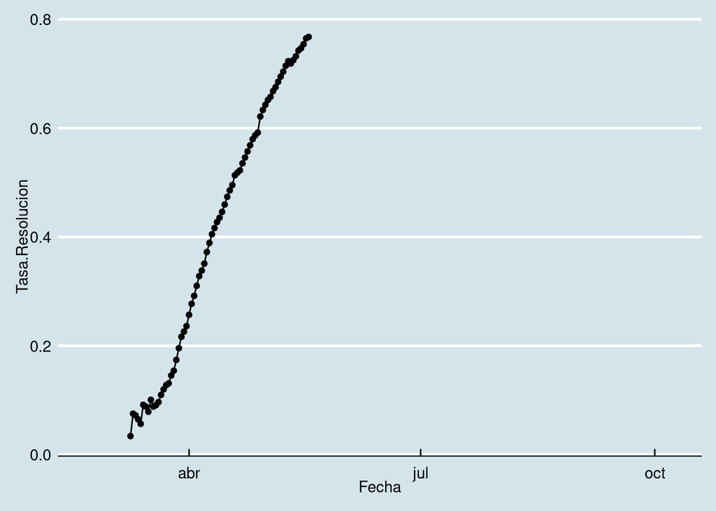

```r
ggplot(data,aes(x=Fecha,y=Tasa.Resolucion))+geom_point()+geom_line()+theme_economist()
```

Como el día 19 de mayo dejaron de dar oficialmente las altas, se quebró la serie temporal en ese momento. Quizás con la relativa (es decir, lo mismo calculado puntualmente para cada día con deltas desde el día anterior) el panorama sea un poco más claro:

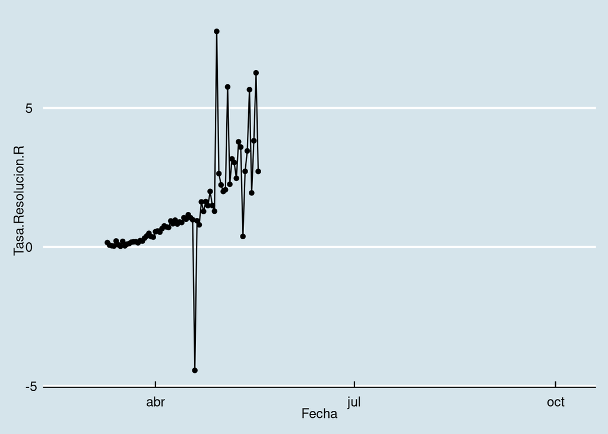

```r
ggplot(data,aes(x=Fecha,y=Tasa.Resolucion.R))+geom_point()+geom_line()+theme_economist()
```

Finalmente, la prevalencia teórica: el número de contagiados hace 14 días (la duración de la cuarentena) menos los fallecidos y curados hoy.

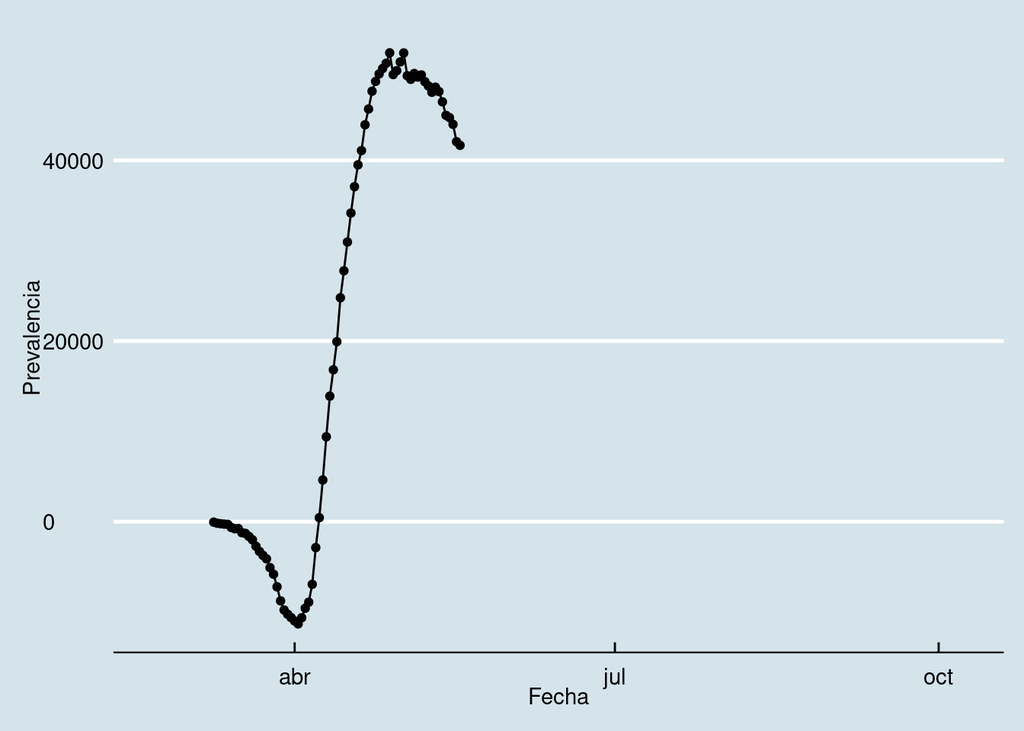

```r
ggplot(data,aes(x=Fecha,y=Prevalencia))+geom_point()+geom_line()+theme_economist()
```

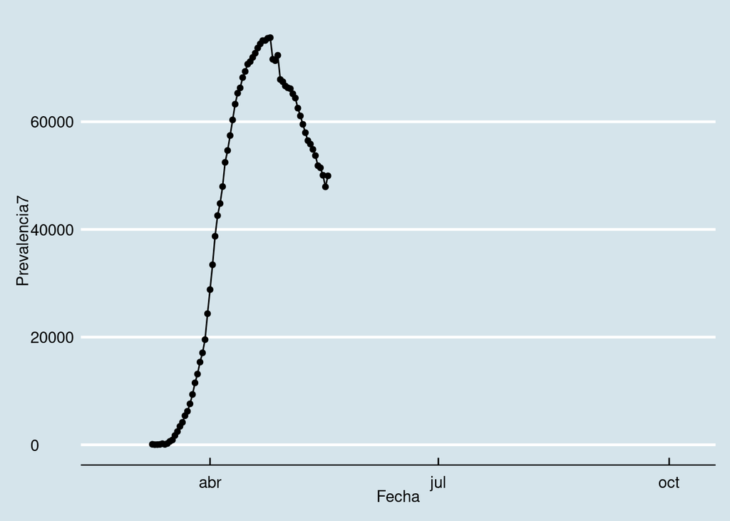

```r
ggplot(data,aes(x=Fecha,y=Prevalencia7))+geom_point()+geom_line()+theme_economist()
```

## Reconocimientos.

Este fichero está generado a partir de los datos elaborados por [Datadista](https://github.com/datadista/datasets) y tiene una licencia libre. Se puede generar con nuevos datos usando el script en [este repositorio](https://github.com/JJ/covid-reports).